# INTRODUCTION TO R PROGRAMMING

# 5 Mapping Aesthetics

Review the syntax for ggplot2 again.

📜 The SYNTAX (basic): `ggplot(data = df, mapping = aes(x, y, other aesthetics))`

The `aes()` argument supplies mapping information. Mapping refers to connecting your data variables to visual properties (aesthetics) of the plot. It’s how you tell ggplot which column in your data should control which aspect of the visualization.

```r
?aes
```

🎯 The GOAL: Map divorce rate to the x-axis and margarine consumption to the y-axis using `aes()`.

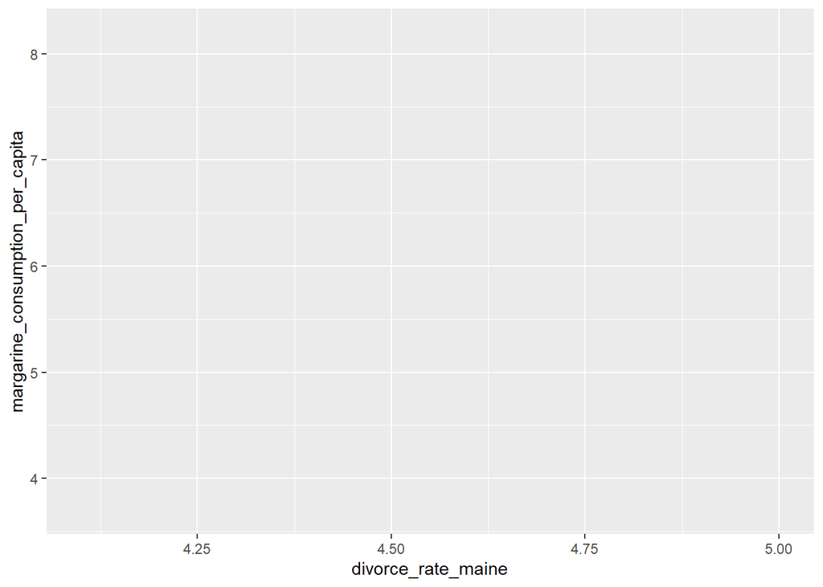

```r
# ⚡Code Example: Mapping aesthetics
divorce_margarine %>%
  ggplot(aes(x = divorce_rate_maine, y = margarine_consumption_per_capita))
```

🗣 Comment: The plot is still blank because we haven’t added any geometric objects (geoms) yet. The axes are now labeled by the mapped variables, even if there are no points yet. `aes()` connects data columns to visual positions. The `aes()` step comes before choosing a geom because we are first defining the mapping (what goes on the x- and y-axes, colors, etc.) and then deciding how to draw those mapped variables (points, lines, bars, etc.).

🪞 Reflection: The aesthetics describe the underlying structure of the plot, and the geoms are just different ways of rendering that structure. By setting `aes()` inside `ggplot()` we create a shared mapping that all later geoms can reuse, instead of repeating ourselves for each layer.

# 6 Adding Geometric Objects (Geoms)

Geometric objects (geoms) are the actual shapes drawn on the plot: points, lines, bars, boxplots, etc. Each geom answers the question: *Given these aesthetics, how should the data be drawn?*

## 6.1 Scatterplot Example

`geom_point()` is a geometric object (or “geom”) in `ggplot2` that creates a scatter plot by placing points at the specified x and y coordinates.

```r
?geom_point
```

📜 The SYNTAX:

`geom_point(mapping = NULL, data = NULL, ..., na.rm = FALSE, show.legend = NA, inherit.aes = TRUE)`

🧐 Notice that all of the arguments are have default settings because `geom_point()` can inherit the data and aesthetic mappings from the initial `ggplot()` call.

👉 When using ggplot2, geoms are added to the plot using the `+` operator.

1. 🎯 The GOAL: Add points to the plot using `geom_point()`.

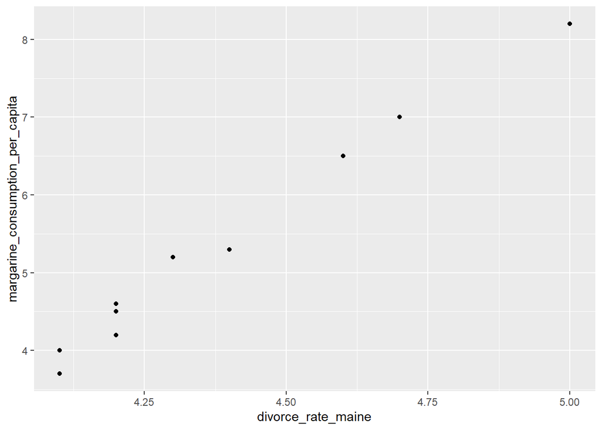

```r
# ⚡Code Example: Scatterplot
divorce_margarine %>%
  ggplot(aes(divorce_rate_maine, margarine_consumption_per_capita)) +
  geom_point()
```

🗣 Comment: There are points showing a linear, positive association between divorce rate and margarine consumption per capita.

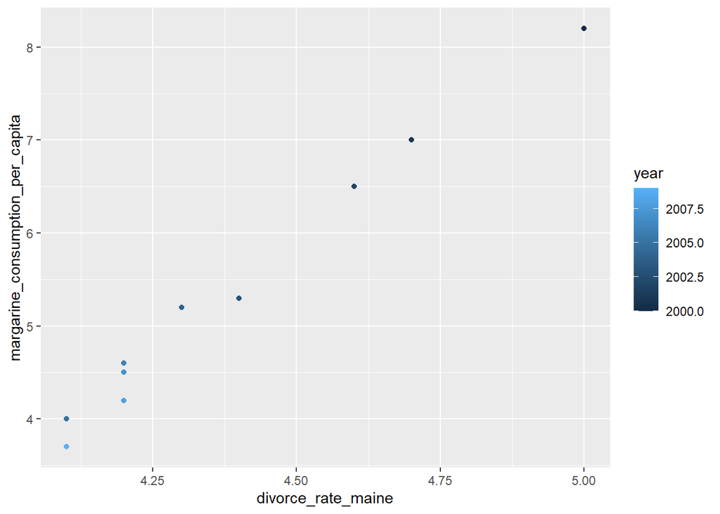

```r
divorce_margarine %>%
  ggplot(aes(x = divorce_rate_maine,   # Global aes mapping: x-axis
             y = margarine_consumption_per_capita)) + # Global aes mapping: y-axis
  geom_point(aes(color = year))        # Local aes mapping: color points by year
```

🤔 Wait, you might by thinking, “`aes()` is already defined in `ggplot()`, why are we using it again in `geom_point()`?” The `aes()` in `ggplot()` are global mappings for the entire plot and apply to all layers. When we use `aes()` inside a specific geom like `geom_point()`, we’re defining mappings that are specific to that layer. This allows for more granular control over how different layers of the plot behave.

`geom_point()` understands these aesthetics:

- x, y: Position (required)
- alpha: Transparency
- color: Point color
- fill: Fill color (for shapes with fill)
- shape: Point shape (0-25)
- size: Point size
- stroke: Border thickness

🚀 Explore and Play: Try adding any of the above aesthetics to `geom_point()`. How does it change the plot?

## 6.2 Layering geoms

Different geoms tell different stories. Let’s explore more geoms!

We’ve seen that `geom_point()` highlights individual data points. `geom_smooth()` adds a smoothed line to show trends in the data.

```r
?geom_smooth
```

📜 The SYNTAX:

`geom_smooth(mapping = NULL, data = NULL, method = NULL, se = TRUE, ...)`

Look at the argument `method`: This controls the smoothing method used. Common options include:

- “lm”: Linear model (straight line)
- “loess”: Local regression (curved line)

🎯 The GOAL: Add `geom_smooth()` to the scatterplot.

Since the relationship looks linear, we’ll use `method = "lm"` to fit a straight line. We’ll also set `se = FALSE` to hide the confidence interval around the line for clarity.

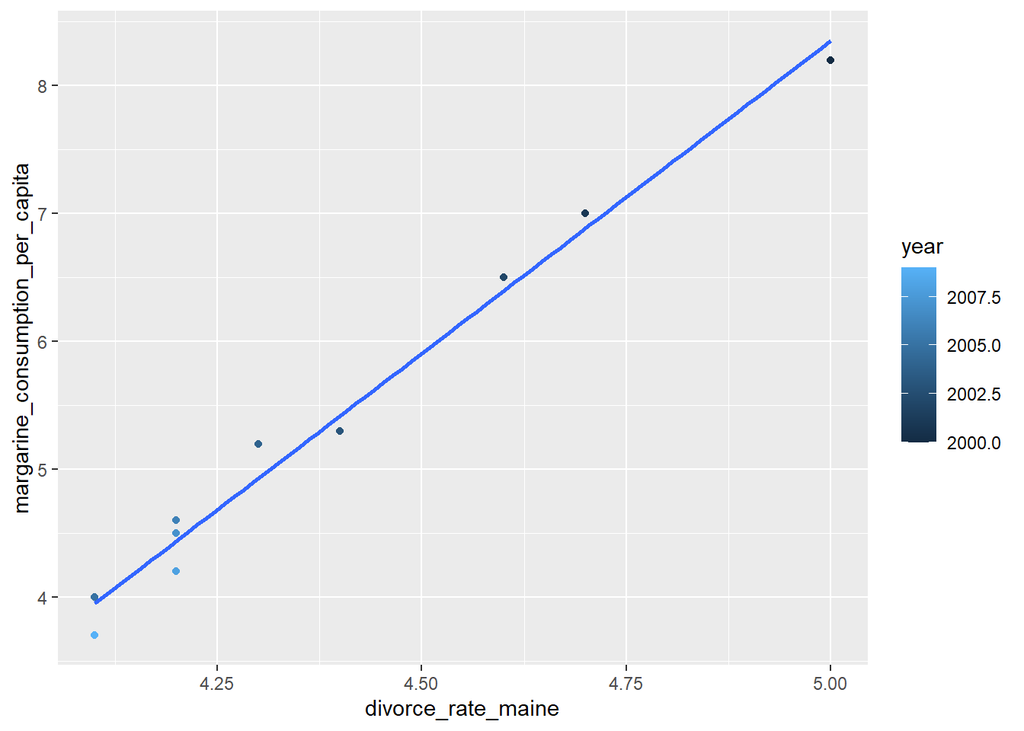

```r
# ⚡Code Example: Scatterplot with trend line
divorce_margarine %>%
  ggplot(aes(x = divorce_rate_maine,
             y = margarine_consumption_per_capita)) +
  geom_point(aes(color = year)) +          # Scatter points
  geom_smooth(method = "lm", se = FALSE)   # Add linear trend line
```

🗣 Comment: The trend line shows a positive linear relationship between divorce rate and margarine consumption.

## 6.3 Histogram Example

```r
?geom_histogram
```

📜 The SYNTAX:

`geom_histogram(mapping = NULL, data = NULL, ..., binwidth = NULL, bins = NULL, na.rm = FALSE, show.legend = NA, inherit.aes = TRUE)`

Let’s build our own data set to explore histograms.

1. 🎯 The GOAL: Simulate a `Tallness` data frame with heights for 1,000 people in the USA and Canada each. In the column `Country`, make two groups labeled “USA” and “CAN”. USA heights are centered around 67 inches with a standard deviation of 2.5. CAN heights are centered around 66 inches with a standard deviation of 1.5. Tallness follows a normal distribution.

```r
# ⚡Code
set.seed(2025)
Tallness <- data.frame(
  Country = c(rep("USA", 1000), rep("CAN", 1000)),
  Height  = c(rnorm(1000, 67, 2.5), rnorm(1000, 66, 1.5))
)
```

```r
# ✅ Verify Tallness data frame
nrow(Tallness)
Tallness %>%
  group_by(Country)%>%
  summarize(n = n(),
            mean_height = mean(Height),
            sd_height = sd(Height),
            .groups = "drop")
```

[output not shown]

🗣 Comment: We have 2,000 rows, 1,000 for each of the two country labels, and heights roughly around expected means and standard deviation.

2. 🎯 The GOAL: Build a histogram of heights using `geom_histogram()`.

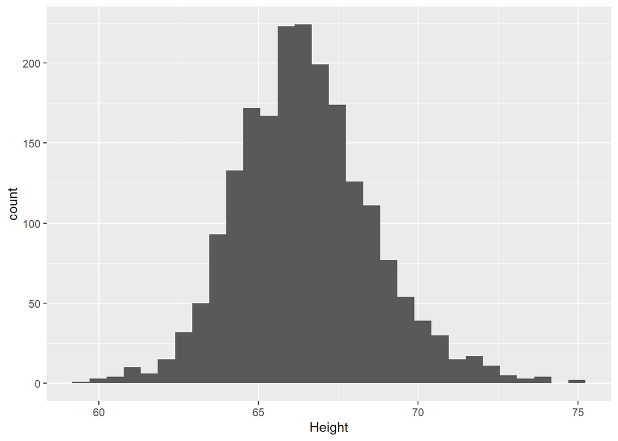

```r
# ⚡Code Example: Histogram
Tallness %>%
  ggplot(aes(Height)) +    # only x for histograms
  geom_histogram()
```

🗣 Comment: Histograms visualize the distribution of a single continuous variable. `geom_histogram()` uses the global `x` aesthetic (`Height`) and so there is no need to repeat the `aes()` inside of the `geom_histogram()` argument. Additionally, the `y` is computed, not mapped. `geom_histogram()` uses `stat_bin()` “under the hood” to compute the counts (or density). This is why we do not need to map a column to `y`. The y-values are produced by the statistic.

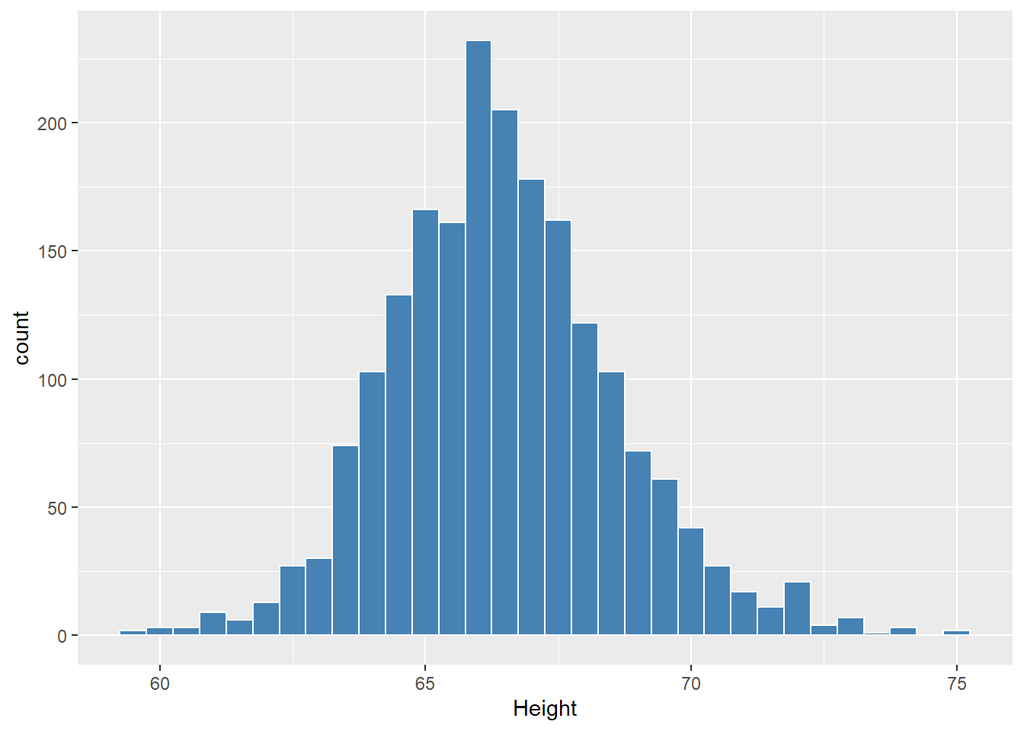

```r
# ⚡Code Example: Customized Histogram
Tallness %>%
  ggplot(aes(Height)) +                # only x for histograms
  geom_histogram(fill = "steelblue",
                 color = "white",      # white border gives gap between bars
                 binwidth = 0.5)       # Set bin width to 0.5
```

🚀 Explore and Play: Change `binwidth = 0.25` inside `geom_histogram()`. Are the overall center and spread the same, even though the “smoothness” changes? Reflect on how binwidth trades off smooth vs. noisy appearance and what you’d choose for a report.

🛠 Break Things! Test out your hand at adding aesthetics `geom_histogram()` understands.

## 6.4 Density Plot

Now we’ll look at a smooth version of the height distribution using a density curve.

Density plots are smoothed versions of histograms that estimate the probability density function of a continuous variable. They are useful for visualizing the distribution shape without the binning artifacts of histograms.

```r
?geom_density
```

📜 The SYNTAX:

`geom_density(mapping = NULL, data = NULL, ..., na.rm = FALSE, show.legend = NA, inherit.aes = TRUE)`

🎯 The GOAL: Make a smooth density plot of heights in the `Tallness` data and emphasize that the vertical axis is density, not counts. Add a density layer that shows a smooth curve for the distribution of heights. Fill the area under the curve, make it partially transparent so the shape is not too heavy.

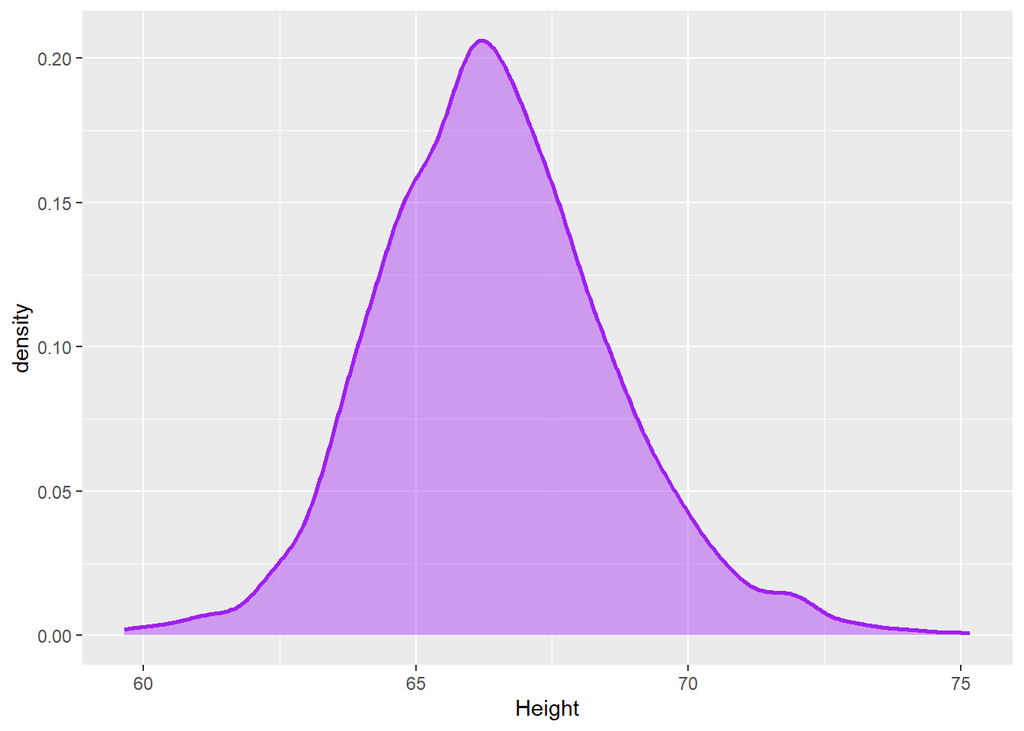

```r
# ⚡Code Example: Density Plot
Tallness %>%
  ggplot(aes(x = Height)) +
  geom_density(fill     = "purple",
               alpha    = 0.4,
               color    = "purple",
               linewidth = 1)
```

`geom_density()` uses kernel density estimation to create a smooth curve that represents the distribution of the data.

- `x` is the variable whose distribution you want to smooth and is usually entered in `ggplot(aes())`.
- `geom_density()` computes the vertical axis as density by default; the y-values are not mapped from a column.
- `fill` sets the interior color of the density shape.
- `alpha` controls transparency (0 = fully transparent, 1 = solid).
- `color` sets the outline color.
- `linewidth` controls the thickness of the outline.

## 6.5 Overlaid Histograms

Let’s compare the two height distributions by overlaying histograms and using `fill = Country` to distinguish groups.

🎯 The GOAL: Compare height distributions between USA and CAN by overlaying two histograms using `fill = Country`. Let’s store the graph as `tall_compared_fig`. Then, we’ll print the figure to take a look.

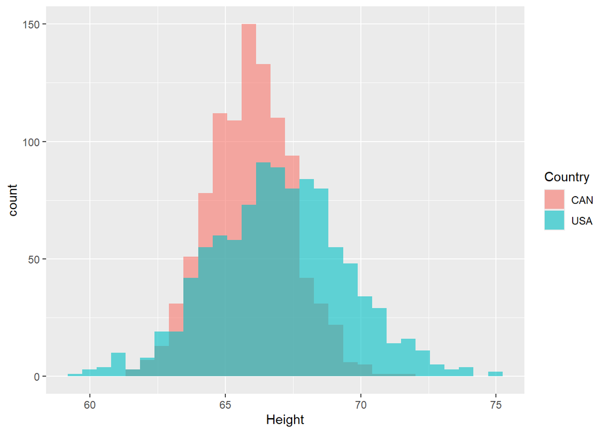

```r
# ⚡Code Example: Overlaid Histograms
tall_compared_fig <- Tallness %>%
  ggplot(aes(Height, fill = Country)) +
  geom_histogram(position = "identity",
                 alpha = 0.6)           # Set transparency to see overlap
# ✅ Print the figure
print(tall_compared_fig)
```

🗣 Comment: `fill = Country` in the global `aes()` tells `ggplot()` to make a separate histogram for each country with different fill colors, and automatic a legend. By default, `geom_histogram()` stacks groups. The `position = "identity"` instead puts the bars in the same x-scale so they overlap. The `alpha = 06` makes bars transparent (0 = invisible, 1 = solid), so we can see where the two distributions overlap.

## 6.6 Boxplot

Boxplots summarize distributions using five statistics: minimum, first quartile (Q1), median, third quartile (Q3), and maximum. They are useful for comparing distributions across groups.

```r
?geom_boxplot
```

📜 The SYNTAX:

`geom_boxplot(mapping = NULL, data = NULL, ..., outlier.color = NULL, outlier.shape = 19, outlier.size = 1.5, na.rm = FALSE, show.legend = NA, inherit.aes = TRUE)`

We can use boxplots to compare height distributions between USA and CAN.

🎯 The GOAL: Build side-by-side boxplots of height by country using `geom_boxplot()`. Map `Country` to the x-axis and `Height` to the y-axis. Use `fill = Country` to color the boxes by country and set `show.legend = FALSE` to hide the legend. We’ll store the boxplot as `Tall_Box`.

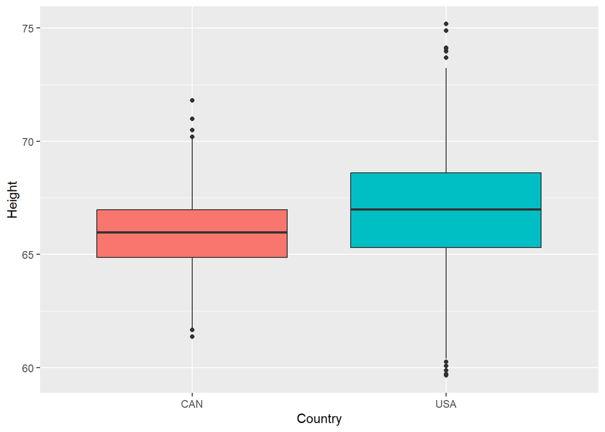

```r
# ⚡Code Example: Boxplot
Tall_Box <- Tallness %>%
  ggplot(aes(Country, Height, fill = Country)) +
  geom_boxplot(show.legend = FALSE)
# ✅Print the boxplot
Tall_Box
```

🗣 Comment: There are two boxes, one for each country, with USA maybe a bit higher median and wider spread. The countries appear on the x-axis and that each box shows median, IQR, and dots for each of the outliers.

# 7 Labels and Themes

We can enhance our plots by adding axis labels and applying themes for better aesthetics.

`xlab()` and `ylab()` functions set the labels for the x and y axes, respectively. Simply type the desired label text as a string inside the function.

Additionally, `ggtitle()` adds a title to the plot.

Type `?theme_bw` to explore available themes in `ggtheme {ggplot2}`

🎯 The GOAL: Add axis labels and a light theme to the boxplot of height by country.

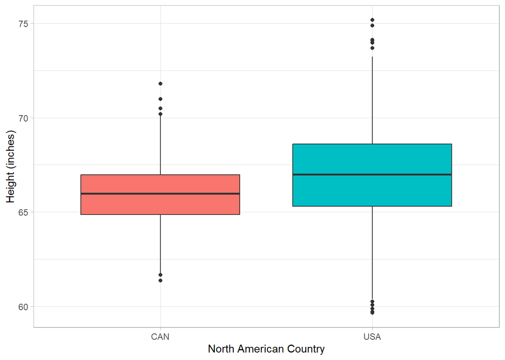

```r
# ⚡Code Example: Boxplot with labels and theme
Tall_Box <- Tallness %>%
  ggplot(aes(Country, Height, fill = Country)) +
  geom_boxplot(show.legend = FALSE) +
  xlab("North American Country") +
  ylab("Height (inches)") +
  ggplot2::theme_light()
# ✅Print the boxplot
Tall_Box
```

# 8 ➤ Assignment

To earn technical skill points, replace each ____ placeholder (and any TODO comments) with working code or a short written answer. Run each section. When you’re done, your workspace should contain FOUR new objects: `Pretty_Flowers`, `Petal_Spread`, `CO2_Graph`, `Tall_Density`. Run each section so that the requested objects appear in your Environment. Save and submit both the “your choice” file with your code (R, Rmd, or Qmd) and the data in your environment (RData). The highest points you can earn in the technical skill practice portion are 3.50.

For every code chunk you add or edit, use the **🎯/❓ Goal → ⚡Code attempts → ✅Checks (print the figures) → 🗣/🪞 Explain the code, the results or what you learned** structure to earn learning skill points. The highest learning skill points you can earn on this submission is 2.50.

## 8.1 Task 0

📦 Packages

Make sure your script includes code that attached `ggplot2`, `dplyr`, and `dslabs` packages so that your script runs from start to finish without errors.

## 8.2 Task 1

🧠 Quick Recall

List the three core `ggplot2` steps and write a short explanation of each step.

✍️ EXPLANATION: “___”

✍️ EXPLANATION: “___”

✍️ EXPLANATION: “___”

## 8.3 Task 2

**Scatterplot**

Create a scatterplot from the built-in `iris` dataset, and save it in an object called `Pretty_Flowers`. Put sepal length on the horizontal axis and petal length on the vertical axis. Color the points by species so that each species has a different color. Make the points moderately large so they are easy to see. Finally, label the x-axis as “Sepal Length (cm)” and the y-axis as “Petal Length (cm)”.

```r
# ⚡Code
_____ <- _____
```

## 8.4 Task 3

**Boxplot: Group Comparison**

Create a boxplot from the built-in iris dataset and store it in an object called `Petal_Spread`. Put species on the horizontal axis and petal width on the vertical axis. For each species, draw a separate boxplot showing the spread and typical values of petal width. Fill each box with a different color according to species, but remove the legend so only the colored boxplots and axis labels indicate which species is which.

```r
# ⚡Code
_____ <- _____
```

## 8.5 Task 4

**Density plot: split + transparency**

Create a density plot using the built-in `CO2` dataset and store the plot in an object called `CO2_Graph`. Put CO2 uptake on the horizontal axis. Use plant type to define separate smooth curves, so each plant type has its own density curve filled with a different color. Make the filled areas partially transparent so the curves can overlap and still be visible where they intersect. Finally, add the title “CO2 Uptake by Plant Type” (use `ggtitle()`) at the top of the plot.

```r
# ⚡Code
_____ <- _____
```

## 8.6 Task 5

⚖️ Histogram vs. Density

Create a graph from the `heights` dataset and save it in an object called `Tall_Density`. Put height (in inches) on the horizontal axis. Draw a histogram of heights using bars that are 1 inch wide, filled in blue with white borders. Scale the histogram so that the vertical axis shows density (proportion), not raw counts. On top of this, add a smooth density curve that shows the overall shape of the height distribution, using a dark orange line. Fill the area under that density curve with the same dark orange color, but make it partially transparent so you can still see the blue histogram bars underneath. Label the x-axis “Height (inches)” and the y-axis “Density” (**Hint**: See Layering geoms and use `geom_histogram()` first, then `geom_density()`.)

```r
# ⚡Code
_____ <- _____
```

## 8.7 Task 6

🤔 Reflect:

📝 Write a short paragraph reflecting on when would a density curve be more useful than a histogram?

✍️ EXPLANATION: “___”

# 9 Save and Upload

1. You will be submitting **both** the “your choice” code file (R, Rmd, Qmd) and the workspace file (RData).

# 10 Today you practiced:

- Created a blank canvas with `ggplot()`.
- Mapped variables inside `aes()`.
- Added geoms for scatter, histogram, and boxplot.
- Used color / fill to compare groups.
- Applied labels and a light theme for clarity.
- Saved plots as objects for submission.